# STK4900 - Lecture 1

Olivia Beyer Bruvik

6/9/2021

# Lecture 1

## Topics

1. Intro / Exam
2. Descriptive methods
3. Data and Probability models
4. Normal distributions
5. Estimation and confidence intervals
6. Hypothesis testing and p-values
7. Robustness and bootstrapping

https://www.uio.no/studier/emner/matnat/math/STK4900/v21/lectures/lecture1.pdf

## Exam

### Format

- Answer questions about analyses of data sets based on given outputs of R
- Exam will be similar to previous years (except 2020)
- All examination aids are allowed

### Submission

- One PDF document
- Take photos of hand writing / R markdown / Word?
- Premake word doc or R markdown with useful notes and equations
- Remove personal info https://www.uio.no/english/studies/examinations/submissions/submit-answer/submit-file-upload.html.

## Descriptive Methods

### Mean, median, SD

- mean, ${\bar{x}=\frac{1}{n}\sum_{i=1}^{n}{\bar{x}}}$
- median, med
- standard deviation, $s = \sqrt{\frac{1}{1-n}sum_{i=1}^{n}(x_i-\bar{x})^2}$

### Illustrations

- histograms
- empirical cumulative distribution (ecdf)
- boxplot

### Data, $\bar{x},...,x_n$

- replications of the same measurement or observations on random sample of population
- numerical or categorical

```r
# Descriptive methods
summary(cars$speed)
```

```
##    Min. 1st Qu.  Median    Mean 3rd Qu.    Max.
##     4.0    12.0    15.0    15.4    19.0    25.0
```

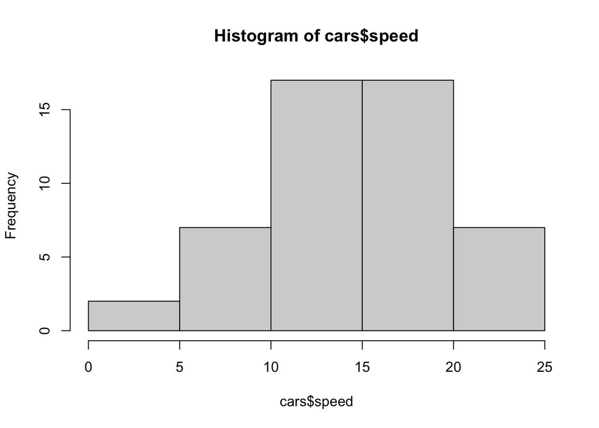

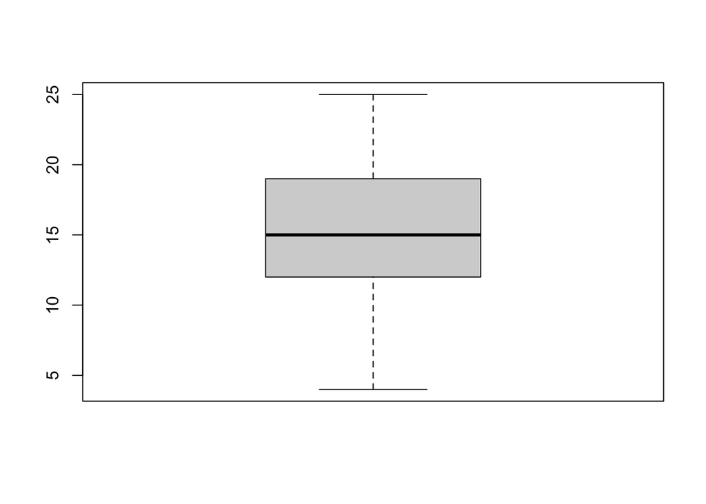

```r
# Illustrations
hist(cars$speed)
boxplot(cars$speed)
```

## Data and Probability models

### Random variable, X

- Data assumed independent replications of a random variable, X
- distribution described by:
1. probability density (histogram), $f(x)$,
2. or a cumulative distribution function (ecdf), $F(x)$

Computing probability that a realization of X falls in a certain interval:
$${P(a<X\leq{b}) = \int_{a}^{b}f(x)dx = F(b) - F(a)}$$

## Normal distributions

### Distributions of continuously distributed random variables

1. Mean or expectation: $\mu = E(X) = \int_{-\infty}^{\infty}xf(x)dx$
2. Variance: $\sigma^2=Var(X)=\int_{-\infty}^{\infty}(x-\mu)^2f(x)dx$
3. Standard variation: $\sigma=sd(X)=\sqrt{Var(X)}$

Similar formulas with sums apply for discrete random variables

### Properties of expectation and variance

$E(a+bX) = a+bE(X)$  
$E(X+Y) = E(X)+E(Y)$

$Var(a+bX)=b^2Var(X)$  
$Var(X+Y)=Var(X)+Var(Y)$, where X and Y are independent

### Law of Large Numbers

Suppose that $\bar{x},...,x_n$ are independent replications of a random variable X with mean $\mu$ and standard deviation $\sigma$, then
$$\bar{x} \to \mu \\
s \to \sigma$$
as $n$ increases.

### Normal distributions

$X \sim N(\mu,\sigma^2)$ - Random variable X is normally distributed with mean $\mu$ and SD $\sigma$.
$$f(x)=\frac{1}{\sigma\sqrt{2\pi}}*e^{-\frac{1}{2}*(\frac{x-\mu}{\sigma})^2}$$

### Standard Normal distribution

$Z \sim N(0,1)$

1. $If \space X \sim N(\mu,\sigma^2), \space then \space Z = \frac{X-\mu}{\sigma} \sim N(0,1)$
2. Suppose that $x_1,...,x_n$ are independent replications of a random variable $X \sim N(\mu,\sigma^2)$, then $\bar{x} \sim N(\mu,\sigma^2/n)$

Central Limit Theorem  
$n \to \infty$: Result two holds approximately also when $x_1,...,x_n$ is a random sample from another distribution than the normal

## Estimation and confidence intervals (14)

### Theta

$\theta$: a parameter describing the probability model (mean or SD), or function of model parameters (coefficient of variation of $\frac{\sigma}{\mu}$).

Mean $\bar{x}$ to estimate the mean $\mu$ of distribution: $\hat{\mu}=\bar{x}$

We consider unbiased estimators, ie. $E(\hat{\theta}) = \theta$

### Standard error

$$se(\hat{\theta}) = \sqrt{Var(\hat{\theta})}$$

$$\hat{\mu} = \bar{x} \to se(\bar{x}) = \frac{\sigma}{\sqrt{n}} = \frac{s}{\sqrt{n}}$$

$$\downarrow se \propto \downarrow s \propto \uparrow n$$

### Confidence Intervals

$$(\hat{\theta} - c * se(\hat{\theta}), \space \hat{\theta} + c*se(\hat{\theta})) = \hat{\theta} \pm c*se(\hat{\theta})$$
#### Confidence Coefficient of Confidence Interval The probability that the interval contains the unknown quantity:
$$P(L< \theta < U) = 1-\alpha$$

### Confidence interval for the mean µ (17)

Suppose $x_1,...,x_n$ is a random sample from $N(\mu,\sigma^2)$.

- $\mu_0$ is the mean for X
- $\hat{x}$ is the empiric mean
- $s$ is the empiric standard deviation

#### Sigma known

$\bar{x} \sim N(\mu, \frac{\sigma^2}{n})$ and a confidence interval takes the form:

$$\bar{x} \pm c * \frac{\sigma}{\sqrt{n}}$$
c is defined by:

$$P(\bar{x} - c * \frac{\sigma}{\sqrt{n}} < \mu < \bar{x} + c * \frac{\sigma}{\sqrt{n}}) = 1- \alpha$$

One may find c from a table of the standard normal distribution. In particular for a 95% CI we have c = 1.96.

#### Sigma unknown

When $\sigma$ is unknown, we estimate the empirical SD, s.

Confidence interval takes the form:

$$\bar{x} \pm c * \frac{s}{\sqrt{n}}$$
Use t-distribution with n-1 df to determine c (95% CI = 2.10).

## Hypothesis testing and p-values

$H_0: \theta \leq \theta_0$ versus the (one-sided) alternative hypothesis $H_A: \theta>\theta_0$.

### P-values

The probability, when $H_0$ is true, that the test statistic is a value equal to or more extreme than the one observed.

Testing null hypothesis, $H_0: \mu \leq \mu_0$, versus the alternative $H_A:\mu > \mu_0$

### Test for the mean µ

#### σ known

We reject $H_0$ for large values of test statistic:

$$z = \frac{\hat{x}-\mu_0}{\frac{\sigma}{\sqrt{n}}}$$
Under $H_0$, the test statistic is standard normally distributed.

Used to compute one-sided P-value:
$$P = P(Z>z), \space where \space Z \sim N(0,1)$$

#### σ unknown

We reject $H_0$ for large values of test statistic:

$$t = \frac{\hat{x}-\mu_0}{\frac{s}{\sqrt{n}}}$$
Under $H_0$, the test statistic is t-distributed w/ n-1 degrees of freedom.

Used to compute one-sided P-value:
$$P = P(T>t), \text{where T is t-distributed with n-1 df}$$

### Comparing two groups

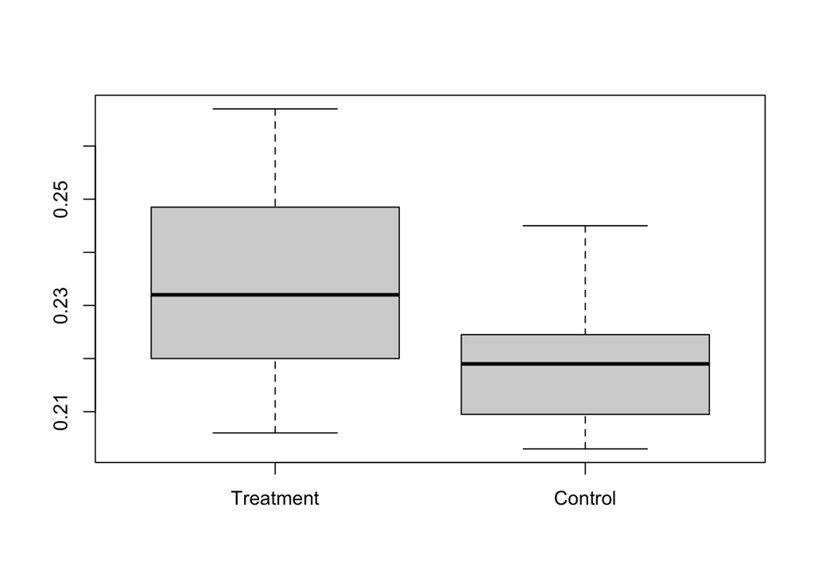

#### Assumption

Equal variances in the two groups, $\sigma_1^2 = \sigma_2^2$

$\mu_2 - \mu_1 \approx \bar{x}_2 - \bar{x}_1$

#### Confidence Intervals

95% confidence interval for $\mu_2 - \mu_1$:
$$\bar{x}_2 - \bar{x}_1 \pm c * se(\bar{x}_2 - \bar{x}_1),\space where \\
\text{c is the upper 97.5% percentile in the t-distribution with n1+n2-2 df}$$

and

$$se(\bar{x}_2 - \bar{x}_1) = s_p \sqrt{(\frac{1}{n_1} + \frac{1}{n_2})}, \space where \\
s_p = \sqrt{\frac{n_1-1}{n_1+n_2-2}s_1^2 + \frac{n_2-1}{n_1+n_2-2}s_2^2}$$

#### Test statistic

$H_0:\mu_1 = \mu_2$ versus the (two-sided) alternative $H_A:\mu_1 \neq \mu_2$

We reject for $H_0$ for large values of test statistic |t|:

$$t = \frac{\bar{x}_2 - \bar{x}_1}{se(\bar{x}_2 - \bar{x})}$$

Under H_0 the test statistic is t-distributed with $n_1+n_2-2$ df.

P-value (two-sided): $P=2P(T>|t|)$, where T is t-distributed with $n_1+n_2-2$ df.

```r
t.test(treat, cont , var.equal=T)
```

```
##
##  Two Sample t-test
##
## data:  treat and cont
## t = 2.8442, df = 28, p-value = 0.008227
## alternative hypothesis: true difference in means is not equal to 0
## 95 percent confidence interval:
##  0.004532839 0.027867161
## sample estimates:
## mean of x mean of y
## 0.2350667 0.2188667
```

## Robustness & Bootstrapping

### Robustness

A method is robust if it is valid also when the modeling assumptions do not hold.

ie. normal distribution assumption –> methods robust with large n because of central limit theorem.

### Bootstrapping

Increase robustness with small datasets.

1. Resample w/ replacement
2. Calculate statistic on bootstrap data set
3. Repeat 1000 times
4. Sort the bootstrap estimates
5. Bootsetrap percentile 95% CI from 2.5-97.5% of bootstrap estimates.